# NeuralNetwork Project by Hari

**• DOMAIN:** Electronics and Telecommunication  
**• CONTEXT:** A communications equipment manufacturing company has a product which is responsible for emitting informative signals. Company wants to build a machine learning model which can help the company to predict the equipment’s signal quality using various parameters.  
**• DATA DESCRIPTION:**  
The data set contains information on various signal tests performed:

1. Parameters: Various measurable signal parameters.
2. Signal_Quality: Final signal strength or quality  
   **• PROJECT OBJECTIVE:** To build a classifier which can use the given parameters to determine the signal strength or quality

**Steps and tasks:**

1. Data import and Understanding  
   A. Read the ‘Signals.csv’ as DataFrame and import required libraries.

```python
import numpy as np
import pandas as pd
import datetime
import pickle
from sklearn import metrics
from sklearn.preprocessing import PolynomialFeatures
from sklearn.model_selection import train_test_split
from sklearn.preprocessing import StandardScaler
from sklearn.preprocessing import MinMaxScaler
from imblearn.over_sampling import SMOTE
```

```python
%tensorflow_version 2.x
import tensorflow as tf
from tensorflow.keras.models import Sequential
from tensorflow.keras.layers import Dense, Dropout, BatchNormalization
from tensorflow.keras import regularizers, optimizers
tf.__version__
```

```
'2.8.0'
```

```python
import plotly.figure_factory as ff
from plotly import express as px
from plotly.subplots import make_subplots
import plotly.graph_objects as go
import matplotlib.pyplot as plt
import seaborn as sns
```

```python
%matplotlib inline
```

```python
from google.colab import drive
drive.mount("/content/drive", force_remount=True)
```

```python
import os
os.chdir("/content/drive/MyDrive/Colab Notebooks//")
```

```python
df = pd.read_csv("Signal.csv")
```

```python
# lets review the data set
df.head()
```

|  | Parameter 1 | Parameter 2 | Parameter 3 | Parameter 4 | Parameter 5 | Parameter 6 | Parameter 7 | Parameter 8 | Parameter 9 | Parameter 10 | Parameter 11 | Signal_Strength |
| --- | --- | --- | --- | --- | --- | --- | --- | --- | --- | --- | --- | --- |
| 0 | 7.4 | 0.70 | 0.00 | 1.9 | 0.076 | 11.0 | 34.0 | 0.9978 | 3.51 | 0.56 | 9.4 | 5 |
| 1 | 7.8 | 0.88 | 0.00 | 2.6 | 0.098 | 25.0 | 67.0 | 0.9968 | 3.20 | 0.68 | 9.8 | 5 |
| 2 | 7.8 | 0.76 | 0.04 | 2.3 | 0.092 | 15.0 | 54.0 | 0.9970 | 3.26 | 0.65 | 9.8 | 5 |
| 3 | 11.2 | 0.28 | 0.56 | 1.9 | 0.075 | 17.0 | 60.0 | 0.9980 | 3.16 | 0.58 | 9.8 | 6 |
| 4 | 7.4 | 0.70 | 0.00 | 1.9 | 0.076 | 11.0 | 34.0 | 0.9978 | 3.51 | 0.56 | 9.4 | 5 |

```python
df.info()
```

```
<class 'pandas.core.frame.DataFrame'>
RangeIndex: 1599 entries, 0 to 1598
Data columns (total 12 columns):
 #   Column           Non-Null Count  Dtype
---  ------           --------------  -----
 0   Parameter 1      1599 non-null   float64
 1   Parameter 2      1599 non-null   float64
 2   Parameter 3      1599 non-null   float64
 3   Parameter 4      1599 non-null   float64
 4   Parameter 5      1599 non-null   float64
 5   Parameter 6      1599 non-null   float64
 6   Parameter 7      1599 non-null   float64
 7   Parameter 8      1599 non-null   float64
 8   Parameter 9      1599 non-null   float64
 9   Parameter 10     1599 non-null   float64
 10  Parameter 11     1599 non-null   float64
 11  Signal_Strength  1599 non-null   int64
dtypes: float64(11), int64(1)
memory usage: 150.0 KB
```

There are no null values in any feature

```python
df.describe()
```

|  | Parameter 1 | Parameter 2 | Parameter 3 | Parameter 4 | Parameter 5 | Parameter 6 | Parameter 7 | Parameter 8 | Parameter 9 | Parameter 10 | Parameter 11 | Signal_Strength |
| --- | --- | --- | --- | --- | --- | --- | --- | --- | --- | --- | --- | --- |
| count | 1599.000000 | 1599.000000 | 1599.000000 | 1599.000000 | 1599.000000 | 1599.000000 | 1599.000000 | 1599.000000 | 1599.000000 | 1599.000000 | 1599.000000 | 1599.000000 |
| mean | 8.319637 | 0.527821 | 0.270976 | 2.538806 | 0.087467 | 15.874922 | 46.467792 | 0.996747 | 3.311113 | 0.658149 | 10.422983 | 5.636023 |
| std | 1.741096 | 0.179060 | 0.194801 | 1.409928 | 0.047065 | 10.460157 | 32.895324 | 0.001887 | 0.154386 | 0.169507 | 1.065668 | 0.807569 |
| min | 4.600000 | 0.120000 | 0.000000 | 0.900000 | 0.012000 | 1.000000 | 6.000000 | 0.990070 | 2.740000 | 0.330000 | 8.400000 | 3.000000 |
| 25% | 7.100000 | 0.390000 | 0.090000 | 1.900000 | 0.070000 | 7.000000 | 22.000000 | 0.995600 | 3.210000 | 0.550000 | 9.500000 | 5.000000 |
| 50% | 7.900000 | 0.520000 | 0.260000 | 2.200000 | 0.079000 | 14.000000 | 38.000000 | 0.996750 | 3.310000 | 0.620000 | 10.200000 | 6.000000 |
| 75% | 9.200000 | 0.640000 | 0.420000 | 2.600000 | 0.090000 | 21.000000 | 62.000000 | 0.997835 | 3.400000 | 0.730000 | 11.100000 | 6.000000 |
| max | 15.900000 | 1.580000 | 1.000000 | 15.500000 | 0.611000 | 72.000000 | 289.000000 | 1.003690 | 4.010000 | 2.000000 | 14.900000 | 8.000000 |

There are skewness in the data and each featue is in different scales

**Steps and tasks:**

1. Data import and Understanding  
   B. Check for missing values and print percentage for each attribute.

```python
def nulsCount(df):
    """summarise missing/unexpected values"""

    d2=pd.DataFrame(columns=["NULL","NAN","BLANKS","UNEXP"])
    try:
        d2["NULL"] = df.isnull().sum().astype('uint32') # check for null values
        d2["NAN"]=df.isna().sum().astype('uint32') # check for NaN
        d2["BLANKS"]=df.isin([""," "]).sum().astype('uint32') # check for blanks
        d2["UNEXP"]=df.isin(["-","?",".","NA","N/A","Unknown"]).sum().astype('uint32') # check for other unexpected values
    except:
        pass
    d2=d2.loc[(d2["NULL"]!=0) | (d2["NAN"]!=0) | (d2["BLANKS"]!=0) | (d2["UNEXP"]!=0)] # shortlist for the missing values

    # convert to percentages
    d2["NULL %"] = d2["NULL"].mul(100/df.shape[0]).round(2)
    d2["NAN %"] = d2["NAN"].mul(100/df.shape[0]).round(2)
    d2["BLANKS %"] = d2["BLANKS"].mul(100/df.shape[0]).round(2)
    d2["UNEXP %"] = d2["UNEXP"].mul(100/df.shape[0]).round(2)

    # rearrange
    d2=d2[["NULL","NULL %","NAN","NAN %","BLANKS","BLANKS %","UNEXP","UNEXP %"]]

    if d2.shape[0]==0:
        return
    else:
        return d2
```

```python
nulsCount(df)
```

Confirming that there are no missing values

**Steps and tasks:**

1. Data import and Understanding  
   C. Check for presence of duplicate records in the dataset and impute with appropriate method.

```python
df.duplicated().sum()
```

```
240
```

240 duplicate records found  
Duplicate records adds no learnable information to the use case. Hence let's drop those duplicated records.

```python
df.drop(df.index[df.duplicated()],axis=0,inplace=True)
```

```python
df.shape #review final shape
```

```
(1359, 12)
```

**Steps and tasks:**

1. Data import and Understanding  
   D. Visualise distribution of the target variable.  
   E. Share insights from the initial data analysis (at least 2).

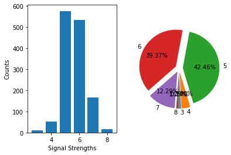

```python
# lets review the distribution of Target Variable "Signal_Strength"
# adding matplotlib graphs for html saving

labels = df.Signal_Strength.value_counts().sort_index().index
values = df.Signal_Strength.value_counts().sort_index().values

fig=plt.figure()

plt.subplot(121)
plt.bar(labels, values)
plt.plot()
plt.xlabel("Signal Strengths")
plt.ylabel("Counts")

plt.subplot(122)
plt.pie(values, labels=labels,
        startangle=270,
        explode = (0.1, 0.1, 0.1,0.1,0.1,0.1),
        autopct = '%1.2f%%')
plt.axis('equal')

fig.show()
```

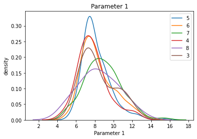

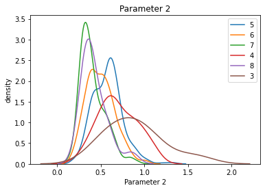

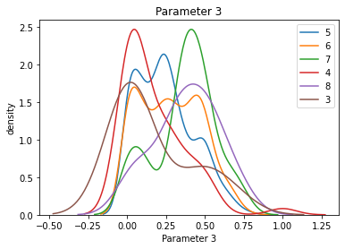

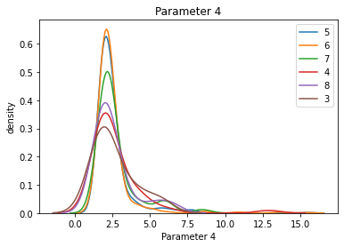

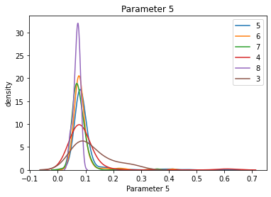

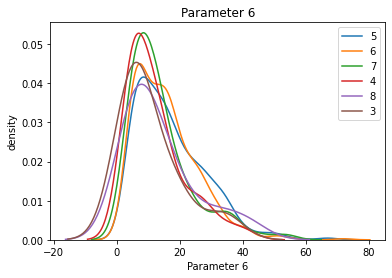

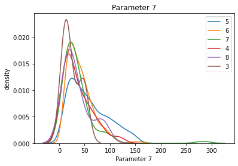

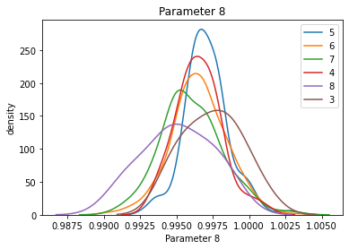

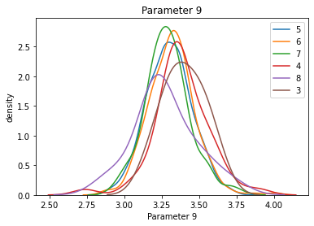

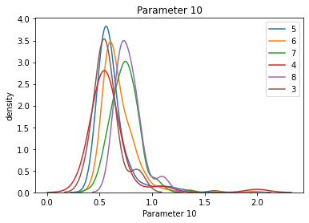

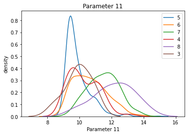

```python
# adding matplotlib graphs for html saving
for col in df.columns[:-1]:
    for i in df.Signal_Strength.unique():
        sns.kdeplot(df[col][df.Signal_Strength == i],label=str(i));
    plt.ylabel('density')
    plt.title(col)
    plt.legend()
    plt.show()
```

**Insights about the data**

1. Signal Strengths 5 &6 dominate the entire spectrum, which could ne learnt by the NN easily, where as due to imbalanced dataset, the classification of the rest will be difficult
2. Majority of the independant variables are skewed (or extremely skewed) and peaky, which might need adequate processing

**2. Data preprocessing**  
A. Split the data into X & Y.  
B. Split the data into train & test with 70:30 proportion.  
C. Print shape of all the 4 variables and verify if train and test data is in sync.

```python
# segregate variables
X=df[df.columns[:-1]].copy()
Y=df[df.columns[-1]].copy()

# Train & Test Split
X_train, X_test, Y_train, Y_test = train_test_split(X, Y,test_size=0.30, # split ratio of 70:30
                                                    random_state=129) # random seed

print("shape of X_train:",X_train.shape)
print("shape of Y_train:",Y_train.shape)
print("shape of X_test:",X_test.shape)
print("shape of Y_test:",Y_test.shape)
```

```
shape of X_train: (951, 11)
shape of Y_train: (951,)
shape of X_test: (408, 11)
shape of Y_test: (408,)
```

```python
408/(951+408)
```

```
0.30022075055187636
```

Both Train & Test X & Y variables are found to have retained the expected dimensions in the expected split ratio

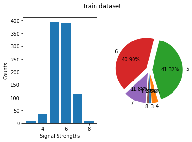

```python
# lets review the distribution of Target Variable "Signal_Strength"
# adding matplotlib graphs for html saving
labels = Y_train.value_counts().sort_index().index
values = Y_train.value_counts().sort_index().values

fig=plt.figure()

plt.subplot(121)
plt.bar(labels, values)
plt.plot()
plt.xlabel("Signal Strengths")
plt.ylabel("Counts")

plt.subplot(122)
plt.pie(values, labels=labels,
        startangle=270,
        explode = (0.1, 0.1, 0.1,0.1,0.1,0.1),
        autopct = '%1.2f%%')
plt.axis('equal')

plt.suptitle("Train dataset")
fig.show()
```

The training dataset approximately captures the distribution of the global set

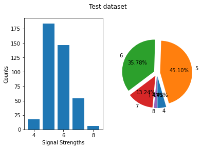

```python
# lets review the distribution of Target Variable "Signal_Strength"
# adding matplotlib graphs for html saving
labels = Y_test.value_counts().sort_index().index
values = Y_test.value_counts().sort_index().values

fig=plt.figure()

plt.subplot(121)
plt.bar(labels, values)
plt.plot()
plt.xlabel("Signal Strengths")
plt.ylabel("Counts")

plt.subplot(122)
plt.pie(values, labels=labels,
        startangle=270,
        explode = (0.1, 0.1, 0.1,0.1,0.1),
        autopct = '%1.2f%%')
plt.axis('equal')

plt.suptitle("Test dataset")
fig.show()
```

The test dataset couldn't represent the global dataset (for instance it misses the Signal_Strength of 3, which was already a minority class in global set)  
This may be rectified if synthetic oversampling was performed (to be attempted at a later stage)

**2. Data preprocessing**  
D. Normalise the train and test data with appropriate method.  
E. Transform Labels into format acceptable by Neural Network.

```python
# Standard Scaling
scl = StandardScaler()
X_train = scl.fit_transform(X_train)
X_test = scl.transform(X_test)
```

```python
# categorical binary encoding
Y_train = tf.keras.utils.to_categorical(Y_train)
Y_test = tf.keras.utils.to_categorical(Y_test)
```

```python
#review shapes of input & output
X_train.shape,Y_train.shape
```

```
((951, 11), (951, 9))
```

**3. Model Training & Evaluation using Neural Network**  
A. Design a Neural Network to train a classifier.  
B. Train the classifier using previously designed Architecture.  
C. Plot 2 separate visuals.  
i. Training Loss and Validation Loss  
ii. Training Accuracy and Validation Accuracy

```python
# initiate network
NN = Sequential()
NN.add(Dense(11, activation="relu"))
NN.add(Dense(20, activation="relu"))
NN.add(Dense(30, activation="relu"))
NN.add(Dense(20, activation="relu"))
NN.add(Dense(10, activation="relu"))
NN.add(Dense(9, activation="softmax"))

# Compile the model
sgd = optimizers.Adam(learning_rate = 0.001)
NN.compile(loss="categorical_crossentropy", metrics=["accuracy"], optimizer=sgd)
```

```python
%%time
# Fit the model
log=NN.fit(x=X_train, y=Y_train, batch_size=32, epochs=50,
           validation_data=(X_test, Y_test),verbose=0)
```

```
CPU times: user 6.74 s, sys: 446 ms, total: 7.19 s
Wall time: 11.5 s
```

```python
# review model architecture
NN.summary()
```

```
Model: "sequential"
_________________________________________________________________
 Layer (type)                Output Shape              Param #
=================================================================
 dense (Dense)               (None, 11)                132

 dense_1 (Dense)             (None, 20)                240

 dense_2 (Dense)             (None, 30)                630

 dense_3 (Dense)             (None, 20)                620

 dense_4 (Dense)             (None, 10)                210

 dense_5 (Dense)             (None, 9)                 99

=================================================================
Total params: 1,931
Trainable params: 1,931
Non-trainable params: 0
_________________________________________________________________
```

```python
# adding matplotlib graphs for html saving
def tensorPlot(log):
    fig=plt.figure()
    x=len(log.history.get('loss'))

    plt.subplot(121)
    plt.plot(np.arange(x), log.history.get('loss'), color='b', label="test_loss")
    plt.plot(np.arange(x), log.history.get('val_loss'), color='r', label="val_loss")
    plt.plot()
    plt.legend()

    plt.subplot(122)
    plt.plot(np.arange(x), log.history.get('accuracy'), color='b', label="test_accuracy")
    plt.plot(np.arange(x), log.history.get('val_accuracy'), color='r', label="val_accuracy")
    plt.plot()
    plt.legend()

    fig.show()
```

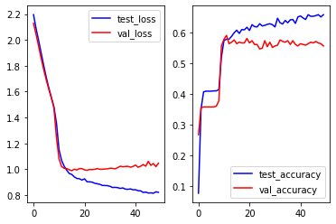

```python
tensorPlot(log)
```

```python
# evaluate the model
[loss,accuracy]=NN.evaluate(X_test, Y_test,verbose=0)
print("Loss     :%.6f"%loss)
print("Accuracy :%.6f"%accuracy)
```

```
Loss     :1.046792
Accuracy :0.556373
```

it is evident from the logs that the network overfitted beyond 10 epoch and thus failing in testing/validation

**3. Model Training & Evaluation using Neural Network**  
D. Design new architecture/update existing architecture in attempt to improve the performance of the model.  
E. Plot visuals as in Q3.C and share insights about difference observed in both the models.

```python
def heatmp(x,y,z):
    df=pd.DataFrame(z,columns=y,index=y)
    fig=plt.figure()
    plt.plot()
    sns.heatmap(df,annot=True,fmt='d',cmap='GnBu')
    fig.show()
```

```python
# classification metrics report
def evalNN(Y_test,prediction):
    pred = (prediction>0.5)
    yt = (Y_test>0.5)
    pred = np.argmax(pred,axis=1)
    yt = np.argmax(yt,axis=1)

    classes=list(np.unique(yt))
    classes.extend(np.unique(pred))
    classes=np.unique(classes)

    z=np.array(pd.DataFrame(metrics.confusion_matrix(yt,pred)))

    heatmp(classes,classes,z)

    print("CLASSIFICATION REPORT\n",metrics.classification_report(yt, pred, digits=3))
```

```python
# lets define a network function
def NNf(data,params,epochs,verbose=False):

    np.random.seed(129)
    tf.random.set_seed(129)

    [X_train,Y_train,X_test,Y_test]=data
    [hl,hln,lr,lmbda,bn,do] = params

    # initiate network
    NN = Sequential()
    init = tf.keras.initializers.GlorotNormal(seed=129)
    NN.add(Dense(len(X_train[0]), input_shape = (len(X_train[0]),), activation = 'relu',kernel_initializer=init))
    for i in range(hl):
        if bn:
            NN.add(BatchNormalization())
        NN.add(Dropout(do))
        NN.add(Dense(hln, activation="relu",kernel_initializer=init))
    if bn:
        NN.add(BatchNormalization())
    NN.add(Dropout(do))
    NN.add(Dense(len(Y_train[0]), activation="softmax",kernel_initializer=init,
                    kernel_regularizer=regularizers.l2(lmbda)))

    # Compile the model
    # sgd = optimizers.Adam(learning_rate = lr, decay=1e-6)
    sgd = optimizers.RMSprop(learning_rate=lr,rho=0.9, momentum=0.1, epsilon=1e-07)

    NN.compile(loss="categorical_crossentropy", metrics=["accuracy"], optimizer=sgd)

    # Fit the model
    log=NN.fit(x=X_train, y=Y_train, batch_size=50, epochs=epochs,
               validation_data=(X_test, Y_test),verbose=0)

    # evaluate the model
    [loss,accuracy] = NN.evaluate(X_test, Y_test,verbose=0)
    if verbose:
        # review model architecture
        display(NN.summary())
        # display the loss & accuracy progress
        tensorPlot(log)
        print("Loss     :%.6f"%loss)
        print("Accuracy :%.6f"%accuracy)

        prediction = NN.predict(X_test)
        evalNN(Y_test,prediction)

    p_acc,p_epoch = np.max(log.history.get('val_accuracy')),np.argmax(log.history.get('val_accuracy'))

    return p_acc,p_epoch
```

```
Model: "sequential_1"
_________________________________________________________________
 Layer (type)                Output Shape              Param #
=================================================================
 dense_6 (Dense)             (None, 11)                132

 batch_normalization (BatchN  (None, 11)               44
 ormalization)

 dropout (Dropout)           (None, 11)                0

 dense_7 (Dense)             (None, 15)                180

 batch_normalization_1 (Batc  (None, 15)               60
 hNormalization)

 dropout_1 (Dropout)         (None, 15)                0

 dense_8 (Dense)             (None, 15)                240

 batch_normalization_2 (Batc  (None, 15)               60
 hNormalization)

 dropout_2 (Dropout)         (None, 15)                0

 dense_9 (Dense)             (None, 15)                240

 batch_normalization_3 (Batc  (None, 15)               60
 hNormalization)

 dropout_3 (Dropout)         (None, 15)                0

 dense_10 (Dense)            (None, 9)                 144

=================================================================
Total params: 1,160
Trainable params: 1,048
Non-trainable params: 112
_________________________________________________________________
```

```
None
```

```
Loss     :1.121897
Accuracy :0.580882
```

```
CLASSIFICATION REPORT
               precision    recall  f1-score   support

           0      0.000     0.000     0.000         0
           4      0.000     0.000     0.000        18
           5      0.786     0.440     0.564       184
           6      0.000     0.000     0.000       146
           7      0.667     0.037     0.070        54
           8      0.000     0.000     0.000         6

    accuracy                          0.203       408
   macro avg      0.242     0.080     0.106       408
weighted avg      0.443     0.203     0.264       408

0.5808823704719543 9
CPU times: user 3.43 s, sys: 188 ms, total: 3.62 s
Wall time: 3.7 s
```

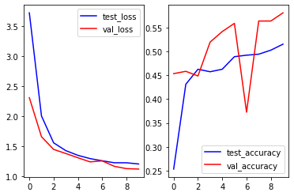

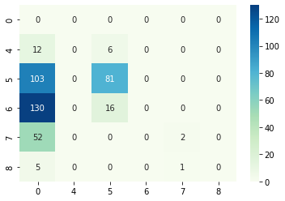

```python
%%time
# tryout the function
hidden_layer = 3
hidden_neurons = 15
learning_rate = 1e-2
Lambda = 0.25
epochs = 10

data = [X_train,Y_train,X_test,Y_test]
params = [hidden_layer,hidden_neurons,learning_rate,Lambda,True,0.5]

p_acc,p_epoch = NNf(data,params,epochs,verbose = True)
print(p_acc,p_epoch)
```

Upon several trial, it was found that the model accuracy flattens under 60%, hence lets try to perform grid search tuning  
in an attempt to balance the classes in training data using oversampling, the performance was found to drop below 40%, hence balancing is given up for the current study  
instead polynomial feature extraction shall be attempted

```python
# segregate variables
X=df[df.columns[:-1]].copy()
Y=df[df.columns[-1]].copy()

# Train & Test Split
X_train, X_test, Y_train, Y_test = train_test_split(X, Y,test_size=0.30, # split ratio of 70:30
                                                    random_state=129) # random seed

# convert to numpy array for uniformity of datatypes
X_train = X_train.values
X_test = X_test.values

# extract polynomial features
poly = PolynomialFeatures(2,interaction_only=True)
X_train = poly.fit_transform(X_train)
X_test = poly.transform(X_test)

# scaling with MinMaxScaler
scl = MinMaxScaler((0,1))
X_tr_mima = scl.fit_transform(X_train)
X_te_mima = scl.transform(X_test)

# scaling with StandardScaler
scl = StandardScaler()
X_tr_std = scl.fit_transform(X_train)
X_te_std = scl.transform(X_test)

# categorical binary encoding
ytr = tf.keras.utils.to_categorical(Y_train)
Y_train = np.array([yn[3:] for yn in ytr]) # remove categories 0,1,2
yte = tf.keras.utils.to_categorical(Y_test)
Y_test = np.array([yn[3:] for yn in yte]) # remove categories 0,1,2
```

```python
# lets create parameter gridpoints
hidden_layers = np.arange(3,6,1)
hidden_neurons = np.arange(40,75,5)
learning_rates = [1e-3,1e-4]
Lambdas = [0.25,0.5,0.75]
bns = [True]#, False]
dos = np.arange(0.2,0.7,0.1)
scales = ['mima']#,'std']

pgrid = [[hl,hn,lr,lm,bn,do,scl]
           for hl in hidden_layers
           for hn in hidden_neurons
           for lr in learning_rates
           for lm in Lambdas
           for bn in bns
           for do in dos
           for scl in scales]

print("number of grid points: ",len(pgrid))
```

```
number of grid points:  630
```

```python
#file = open("NN_tuning.har",'wb') # reset log file
#file.close()

# above file not re-created after setting up a good hypertuning framework
# hence above line commented
```

```python
results = [] # reset local log

file = open("NN_tuning.har",'rb')
read = True
while read:
    try:
        results.append(pickle.load(file))
    except:
        read = False
file.close()

if len(results)>0:
    respg = [i[:-2] for i in results]

for gp in respg:
    try:
        pgrid.remove(gp)
    except:
        pass

print("grid points remaining: ",len(pgrid))
```

```
grid points remaining:  512
```

```python
%%time
# perform random grid search
epochs = 50
nSearch = 10
for niter,iter in enumerate(np.random.randint(0,len(pgrid),nSearch)):
    params = pgrid[iter][:-1]
    if pgrid[iter][-1] == 'mima':
        data = [X_tr_mima,Y_train,X_te_mima,Y_test]
    elif pgrid[iter][-1] == 'std':
        data = [X_tr_std,Y_train,X_te_std,Y_test]

    p_acc,p_epoch = NNf(data,params,epochs,verbose = False)

    storage = pgrid[iter].copy()
    storage.append(p_acc)
    storage.append(p_epoch)
    file = open("NN_tuning.har",'ab')
    pickle.dump(storage,file)
    file.close()

    print("iter %d / %d"%(niter+1,nSearch))
    print(p_acc,p_epoch)
    print("="*50)

file = open("NN_tuning.har",'rb')
read = True
while read:
    try:
        results.append(pickle.load(file))
    except:
        read = False
file.close()

cols=["HiddenLayers","HiddenNeurons","LearningRate","Lambda","BatchNormalization",
         "DropOut","Scaler","PeakAccuracy","PeakEpoch"]

display(pd.DataFrame(results,columns=cols).sort_values(by="PeakAccuracy",ascending=False).head())
```

```
iter 1 / 10
0.6078431606292725 42
==================================================
iter 2 / 10
0.5588235259056091 47
==================================================
iter 3 / 10
0.5245097875595093 49
==================================================
iter 4 / 10
0.6102941036224365 31
==================================================
iter 5 / 10
0.5710784196853638 49
==================================================
iter 6 / 10
0.5980392098426819 32
==================================================
iter 7 / 10
0.6151960492134094 39
==================================================
iter 8 / 10
0.6176470518112183 41
==================================================
iter 9 / 10
0.6004902124404907 40
==================================================
iter 10 / 10
0.6225489974021912 42
==================================================
```

|  | HiddenLayers | HiddenNeurons | LearningRate | Lambda | BatchNormalization | DropOut | Scaler | PeakAccuracy | PeakEpoch |
| --- | --- | --- | --- | --- | --- | --- | --- | --- | --- |
| 478 | 5 | 50 | 0.001 | 0.5 | True | 0.3 | mima | 0.629902 | 23 |
| 232 | 5 | 50 | 0.001 | 0.5 | True | 0.3 | mima | 0.629902 | 23 |
| 205 | 5 | 50 | 0.001 | 0.5 | True | 0.3 | mima | 0.629902 | 23 |
| 207 | 5 | 50 | 0.001 | 0.5 | True | 0.3 | mima | 0.629902 | 23 |
| 480 | 5 | 50 | 0.001 | 0.5 | True | 0.3 | mima | 0.629902 | 23 |

```
CPU times: user 1min 22s, sys: 2.81 s, total: 1min 25s
Wall time: 1min 22s
```

```python
file = open("NN_tuning.har",'rb')
read = True
while read:
    try:
        results.append(pickle.load(file))
    except:
        read = False
file.close()

cols=["HiddenLayers","HiddenNeurons","LearningRate","Lambda","BatchNormalization",
         "DropOut","Scaler","PeakAccuracy","PeakEpoch"]

resdf=pd.DataFrame(results,columns=cols)
resdf.drop(resdf.loc[resdf.duplicated()>0].index,inplace=True)

print("log size: ",len(results))
```

```
log size:  839
```

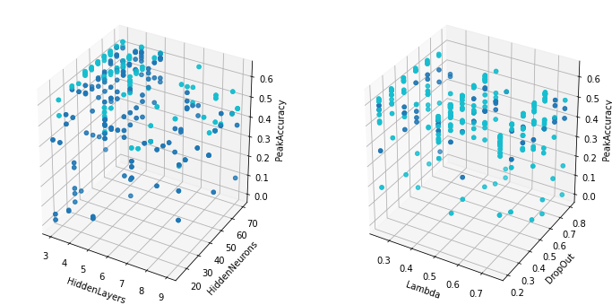

```python
fig = plt.figure(figsize=(12,6))

ax = fig.add_subplot(121, projection='3d')

x = [hl for [hl,hn,lr,lm,bn,do,sc,pa,pe] in results]
y = [hn for [hl,hn,lr,lm,bn,do,sc,pa,pe] in results]
z = [pa for [hl,hn,lr,lm,bn,do,sc,pa,pe] in results]
c = [lr for [hl,hn,lr,lm,bn,do,sc,pa,pe] in results]

ax.scatter(x, y, z, c=c, marker='o',cmap='tab10')
ax.set_xlabel('HiddenLayers')
ax.set_ylabel('HiddenNeurons')
ax.set_zlabel('PeakAccuracy')


ax = fig.add_subplot(122, projection='3d')

x = [lm for [hl,hn,lr,lm,bn,do,sc,pa,pe] in results]
y = [do for [hl,hn,lr,lm,bn,do,sc,pa,pe] in results]
z = [pa for [hl,hn,lr,lm,bn,do,sc,pa,pe] in results]
c = [bn+1 for [hl,hn,lr,lm,bn,do,sc,pa,pe] in results]

ax.scatter(x, y, z, c=c, marker='o',cmap='tab10')
ax.set_xlabel('Lambda')
ax.set_ylabel('DropOut')
ax.set_zlabel('PeakAccuracy')
fig.show()
```

```python
testcases=list(resdf.sort_values(by=["PeakEpoch","PeakAccuracy"],ascending=False).head(2).index)
testcases.extend(list(resdf.sort_values(by=["PeakAccuracy","PeakEpoch"],ascending=False).head(2).index))
testcases=resdf.loc[testcases,["HiddenLayers","HiddenNeurons","LearningRate","Lambda","BatchNormalization","DropOut","Scaler"]].values
```

```python
testcases
```

```
array([[5, 70, 0.0001, 0.5, True, 0.30000000000000004, 'mima'],
       [4, 60, 0.001, 0.75, True, 0.6000000000000001, 'mima'],
       [5, 50, 0.001, 0.5, True, 0.30000000000000004, 'mima'],
       [4, 60, 0.001, 0.75, True, 0.6000000000000001, 'mima']],
      dtype=object)
```

```python
%%time
# Choose the best among above result
epochs = 100
nSearch = len(testcases)

for params in testcases:

    [hl,hn,lr,lm,bn,do,scl]=params
    hl=int(hl)
    hn=int(hn)
    params=[hl,hn,lr,lm,bn,do]
    if scl == 'mima':
        data = [X_tr_mima,Y_train,X_te_mima,Y_test]
    elif scl == 'std':
        data = [X_tr_std,Y_train,X_te_std,Y_test]

    p_acc,p_epoch = NNf(data,params,epochs,verbose = False)

    storage = params.copy()
    storage.append(scl)
    storage.append(p_acc)
    storage.append(p_epoch)
    file = open("NN_tuning.har",'ab')
    pickle.dump(storage,file)
    file.close()

    print(p_acc,p_epoch)
    print("="*50)

file = open("NN_tuning.har",'rb')
read = True
while read:
    try:
        results.append(pickle.load(file))
    except:
        read = False
file.close()

cols=["HiddenLayers","HiddenNeurons","LearningRate","Lambda","BatchNormalization",
         "DropOut","Scaler","PeakAccuracy","PeakEpoch"]

display(pd.DataFrame(results,columns=cols).sort_values(by="PeakAccuracy",ascending=False).head())
```

```
0.593137264251709 56
==================================================
0.6200980544090271 49
==================================================
0.6299019455909729 23
==================================================
0.6200980544090271 49
==================================================
```

|  | HiddenLayers | HiddenNeurons | LearningRate | Lambda | BatchNormalization | DropOut | Scaler | PeakAccuracy | PeakEpoch |
| --- | --- | --- | --- | --- | --- | --- | --- | --- | --- |
| 271 | 5 | 50 | 0.001 | 0.5 | True | 0.3 | mima | 0.629902 | 23 |
| 505 | 5 | 50 | 0.001 | 0.5 | True | 0.3 | mima | 0.629902 | 23 |
| 1110 | 5 | 50 | 0.001 | 0.5 | True | 0.3 | mima | 0.629902 | 23 |
| 1046 | 5 | 50 | 0.001 | 0.5 | True | 0.3 | mima | 0.629902 | 23 |
| 232 | 5 | 50 | 0.001 | 0.5 | True | 0.3 | mima | 0.629902 | 23 |

```
CPU times: user 1min 2s, sys: 2.27 s, total: 1min 4s
Wall time: 52.8 s
```

nearly 350 different models were trained and the performances logged  
Lets review the performances of various models w.r.t. the hyper parameters

It could be infered that with the current dataset, and with not much data preprocessing & feature engineering, the model could learn to a maximum of ~60% accuracy  
Extensive study about the features & better data engineering could help build a better model  
Lets fit the final model based on the grid search and some intuition

Let's review the search log and find a better learner amongst them

```python
resdf.sort_values(by=["PeakAccuracy","PeakEpoch"],ascending=False).head()
```

|  | HiddenLayers | HiddenNeurons | LearningRate | Lambda | BatchNormalization | DropOut | Scaler | PeakAccuracy | PeakEpoch |
| --- | --- | --- | --- | --- | --- | --- | --- | --- | --- |
| 205 | 5 | 50 | 0.001 | 0.50 | True | 0.3 | mima | 0.629902 | 23 |
| 239 | 4 | 60 | 0.001 | 0.75 | True | 0.6 | mima | 0.627451 | 257 |
| 240 | 5 | 45 | 0.001 | 0.50 | True | 0.6 | mima | 0.627451 | 168 |
| 213 | 4 | 40 | 0.001 | 0.25 | True | 0.4 | mima | 0.627451 | 39 |
| 253 | 4 | 55 | 0.001 | 0.25 | True | 0.5 | mima | 0.627451 | 33 |

It turns out that a model that converges at just 23 epochs has been the best model until now, compared to those trained to even 500 epochs.

```
Model: "sequential_16"
_________________________________________________________________
 Layer (type)                Output Shape              Param #
=================================================================
 dense_95 (Dense)            (None, 67)                4556

 batch_normalization_74 (Bat  (None, 67)               268
 chNormalization)

 dropout_74 (Dropout)        (None, 67)                0

 dense_96 (Dense)            (None, 50)                3400

 batch_normalization_75 (Bat  (None, 50)               200
 chNormalization)

 dropout_75 (Dropout)        (None, 50)                0

 dense_97 (Dense)            (None, 50)                2550

 batch_normalization_76 (Bat  (None, 50)               200
 chNormalization)

 dropout_76 (Dropout)        (None, 50)                0

 dense_98 (Dense)            (None, 50)                2550

 batch_normalization_77 (Bat  (None, 50)               200
 chNormalization)

 dropout_77 (Dropout)        (None, 50)                0

 dense_99 (Dense)            (None, 50)                2550

 batch_normalization_78 (Bat  (None, 50)               200
 chNormalization)

 dropout_78 (Dropout)        (None, 50)                0

 dense_100 (Dense)           (None, 50)                2550

 batch_normalization_79 (Bat  (None, 50)               200
 chNormalization)

 dropout_79 (Dropout)        (None, 50)                0

 dense_101 (Dense)           (None, 6)                 306

=================================================================
Total params: 19,730
Trainable params: 19,096
Non-trainable params: 634
_________________________________________________________________
```

```
None
```

```
Loss     :1.105555
Accuracy :0.629902
```

```
CLASSIFICATION REPORT
               precision    recall  f1-score   support

           0      0.000     0.000     0.000         0
           1      0.000     0.000     0.000        18
           2      0.717     0.701     0.709       184
           3      0.525     0.219     0.309       146
           4      1.000     0.056     0.105        54
           5      0.000     0.000     0.000         6

    accuracy                          0.402       408
   macro avg      0.374     0.163     0.187       408
weighted avg      0.643     0.402     0.444       408
```

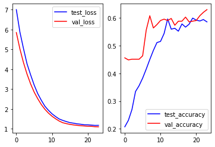

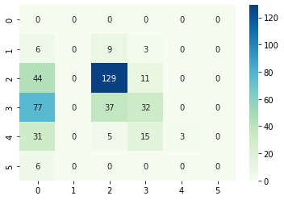

```python
data = [X_tr_mima,Y_train,X_te_mima,Y_test]
params=[5,50,0.001,0.5,True,0.3]
epochs=24
p_acc,p_epoch = NNf(data,params,epochs,verbose=True)
```

# Part Two

**• DOMAIN:** Autonomous Vehicles  
**• CONTEXT:** A Recognising multi-digit numbers in photographs captured at street level is an important component of modern-day map making. A classic example of a corpus of such street-level photographs is Google’s Street View imagery composed of hundreds of millions of geo-located 360-degree panoramic images. The ability to automatically transcribe an address number from a geo-located patch of pixels and associate the transcribed number with a known street address helps pinpoint, with a high degree of accuracy, the location of the building it represents. More broadly, recognising numbers in photographs is a problem of interest to the optical character recognition community.  
While OCR on constrained domains like document processing is well studied, arbitrary multi-character text recognition in photographs is still highly challenging. This difficulty arises due to the wide variability in the visual appearance of text in the wild on account of a large range of fonts, colours, styles, orientations, and character arrangements.  
The recognition problem is further complicated by environmental factors such as lighting, shadows, specularity, and occlusions as well as by image acquisition factors such as resolution, motion, and focus blurs. In this project, we will use the dataset with images centred around a single digit (many of the images do contain some distractors at the sides). Although we are taking a sample of the data which is simpler, it is more complex than MNIST because of the distractors.  
**• DATA DESCRIPTION:** The SVHN is a real-world image dataset for developing machine learning and object recognition algorithms with the minimal requirement on data formatting but comes from a significantly harder, unsolved, real-world problem (recognising digits and numbers in natural scene images). SVHN is obtained from house numbers in Google Street View images. Where the labels for each of this image are the prominent number in that image i.e. 2,6,7 and 4 respectively. The dataset has been provided in the form of h5py files. You can read about this file format here:  
http://docs.h5py.org/en/stable/high/dataset.html  
Acknowledgement: Yuval Netzer, Tao Wang, Adam Coates, Alessandro Bissacco, Bo Wu, Andrew Y. Ng  
Reading Digits in Natural Images with Unsupervised Feature Learning NIPS Workshop on Deep Learning and Unsupervised Feature Learning 2011.  
http://ufldl.stanford.edu/housenumbers as the URL for this site.  
**• PROJECT OBJECTIVE:** To build a digit classifier on the SVHN (Street View Housing Number) dataset.

**Steps and tasks:**

1. Data Import and Exploration  
   A. Read the .h5 file and assign to a variable.  
   B. Print all the keys from the .h5 file.  
   C. Split the data into X_train, X_test, Y_train, Y_test

```python
import h5py
svhn = h5py.File("AV_SVHN.h5",'r') # read the h5 file
```

```python
# print the keys in the file
svhn.keys()
```

```
<KeysViewHDF5 ['X_test', 'X_train', 'X_val', 'y_test', 'y_train', 'y_val']>
```

```python
# obtain all data
h5X_train = np.array(svhn.get('X_train'))
h5X_test = np.array(svhn.get('X_test'))
h5X_val = np.array(svhn.get('X_val'))
h5Y_train = np.array(svhn.get('y_train'))
h5Y_test = np.array(svhn.get('y_test'))
h5Y_val = np.array(svhn.get('y_val'))
```

1. Data Visualisation and preprocessing  
   A. Print shape of all the 4 data split into x, y, train, test to verify if x & y is in sync.  
   B. Visualise first 10 images in train data and print its corresponding labels.

```python
print("Train",h5X_train.shape,h5Y_train.shape)
print("Test",h5X_test.shape,h5Y_test.shape)
print("Validation",h5X_val.shape,h5Y_val.shape)
```

```
Train (42000, 32, 32) (42000,)
Test (18000, 32, 32) (18000,)
Validation (60000, 32, 32) (60000,)
```

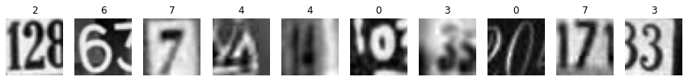

```python
fig = plt.figure(figsize=(15,5))
for i in range(10):
    plt.subplot(1,10,i+1)
    plt.imshow(h5X_train[i],cmap='binary')
    plt.axis('off')
    plt.title(h5Y_train[i])
fig.show()
```

C. Reshape all the images with appropriate shape update the data in same variable.  
D. Normalise the images i.e. Normalise the pixel values.  
E. Transform Labels into format acceptable by Neural Network  
F. Print total Number of classes in the Dataset.

```python
# Reshape
ind=len(h5X_train)
temp=np.zeros((ind,32*32))
for i in range(ind):
    temp[i] = h5X_train[i].reshape(32*32)
h5X_train=temp

ind=len(h5X_test)
temp=np.zeros((ind,32*32))
for i in range(ind):
    temp[i] = h5X_test[i].reshape(32*32)
h5X_test=temp

ind=len(h5X_val)
temp=np.zeros((ind,32*32))
for i in range(ind):
    temp[i] = h5X_val[i].reshape(32*32)
h5X_val=temp
```

```python
print("Train",h5X_train.shape,h5Y_train.shape)
print("Test",h5X_test.shape,h5Y_test.shape)
print("Validation",h5X_val.shape,h5Y_val.shape)
```

```
Train (42000, 1024) (42000,)
Test (18000, 1024) (18000,)
Validation (60000, 1024) (60000,)
```

```python
# Normalize
h5X_train/=255
h5X_test/=255
h5X_val/=255
```

```python
# review number of classes in data
np.unique(h5Y_train)
```

```
array([0, 1, 2, 3, 4, 5, 6, 7, 8, 9], dtype=uint8)
```

```python
# total number of classes
len(np.unique(h5Y_train))
```

```
10
```

```python
# transform labels to categorical
h5Y_train=tf.keras.utils.to_categorical(h5Y_train)
h5Y_test=tf.keras.utils.to_categorical(h5Y_test)
h5Y_val=tf.keras.utils.to_categorical(h5Y_val)
```

```python
print("Train",h5X_train.shape,h5Y_train.shape)
print("Test",h5X_test.shape,h5Y_test.shape)
print("Validation",h5X_val.shape,h5Y_val.shape)
```

```
Train (42000, 1024) (42000, 10)
Test (18000, 1024) (18000, 10)
Validation (60000, 1024) (60000, 10)
```

1. Model Training & Evaluation using Neural Network  
   A. Design a Neural Network to train a classifier.  
   B. Train the classifier using previously designed Architecture (Use best suitable parameters).  
   C. Evaluate performance of the model with appropriate metrics.  
   D. Plot the training loss, validation loss vs number of epochs and training accuracy, validation accuracy vs number of epochs plot and write your observations on the same.

```python
# classification metrics report
def evalNN(Y_test,prediction):
    pred = (prediction>0.5)
    yt = (Y_test>0.5)
    pred = np.argmax(pred,axis=1)
    yt = np.argmax(yt,axis=1)

    classes=list(np.unique(yt))
    classes.extend(np.unique(pred))
    classes=np.unique(classes)

    z=np.array(pd.DataFrame(metrics.confusion_matrix(yt,pred)))

    heatmp(classes,classes,z)

    print("CLASSIFICATION REPORT\n",metrics.classification_report(yt, pred, digits=3))
```

```python
# lets define a network function
def NNimg(data,params,epochs,verbose=False):

    np.random.seed(129)
    tf.random.set_seed(129)

    [X_train,Y_train,X_test,Y_test]=data
    [hl,hln,lr,lmbda,do] = params

    # initiate network
    NN = Sequential()
    init = tf.keras.initializers.GlorotNormal(seed=129)
    NN.add(Dense(len(X_train[0]), input_shape = (len(X_train[0]),), activation = 'relu',kernel_initializer=init))
    for i in range(hl):
        NN.add(BatchNormalization())
        NN.add(Dropout(do))
        NN.add(Dense(hln, activation="relu",kernel_initializer=init))
    NN.add(BatchNormalization())
    NN.add(Dropout(do))
    NN.add(Dense(len(Y_train[0]), activation="softmax",kernel_initializer=init,
                    kernel_regularizer=regularizers.l2(lmbda)))

    # Compile the model
    # sgd = optimizers.Adam(learning_rate = lr, decay=1e-6)
    sgd = optimizers.RMSprop(learning_rate=lr,rho=0.9, momentum=0.1, epsilon=1e-07)

    NN.compile(loss="categorical_crossentropy", metrics=["accuracy"], optimizer=sgd)

    # Fit the model
    log=NN.fit(x=X_train, y=Y_train, batch_size=50, epochs=epochs,
               validation_data=(X_test, Y_test),verbose=0)

    # evaluate the model
    [loss,accuracy] = NN.evaluate(X_test, Y_test,verbose=0)
    if verbose:
        # review model architecture
        display(NN.summary())
        # display the loss & accuracy progress
        tensorPlot(log)
        print("Loss     :%.6f"%loss)
        print("Accuracy :%.6f"%accuracy)

        prediction = NN.predict(X_test)
        evalNN(Y_test,prediction)

    p_acc,p_epoch = np.max(log.history.get('val_accuracy')),np.argmax(log.history.get('val_accuracy'))

    return p_acc,p_epoch
```

```
Model: "sequential_17"
_________________________________________________________________
 Layer (type)                Output Shape              Param #
=================================================================
 dense_102 (Dense)           (None, 1024)              1049600

 batch_normalization_80 (Bat  (None, 1024)             4096
 chNormalization)

 dropout_80 (Dropout)        (None, 1024)              0

 dense_103 (Dense)           (None, 20)                20500

 batch_normalization_81 (Bat  (None, 20)               80
 chNormalization)

 dropout_81 (Dropout)        (None, 20)                0

 dense_104 (Dense)           (None, 20)                420

 batch_normalization_82 (Bat  (None, 20)               80
 chNormalization)

 dropout_82 (Dropout)        (None, 20)                0

 dense_105 (Dense)           (None, 20)                420

 batch_normalization_83 (Bat  (None, 20)               80
 chNormalization)

 dropout_83 (Dropout)        (None, 20)                0

 dense_106 (Dense)           (None, 20)                420

 batch_normalization_84 (Bat  (None, 20)               80
 chNormalization)

 dropout_84 (Dropout)        (None, 20)                0

 dense_107 (Dense)           (None, 20)                420
```

[output cut: 33 more lines]

```

 dense_112 (Dense)           (None, 20)                420

 batch_normalization_90 (Bat  (None, 20)               80
 chNormalization)

 dropout_90 (Dropout)        (None, 20)                0

 dense_113 (Dense)           (None, 10)                210

=================================================================
Total params: 1,078,986
Trainable params: 1,076,538
Non-trainable params: 2,448
_________________________________________________________________
```

```
None
```

```
Loss     :2.310784
Accuracy :0.093611
```

```
CLASSIFICATION REPORT
               precision    recall  f1-score   support

           0      0.101     1.000     0.183      1814
           1      0.000     0.000     0.000      1828
           2      0.000     0.000     0.000      1803
           3      0.000     0.000     0.000      1719
           4      0.000     0.000     0.000      1812
           5      0.000     0.000     0.000      1768
           6      0.000     0.000     0.000      1832
           7      0.000     0.000     0.000      1808
           8      0.000     0.000     0.000      1812
           9      0.000     0.000     0.000      1804

    accuracy                          0.101     18000
   macro avg      0.010     0.100     0.018     18000
weighted avg      0.010     0.101     0.018     18000

0.1007777750492096 2
CPU times: user 1min 56s, sys: 5.12 s, total: 2min 1s
Wall time: 1min 22s
```

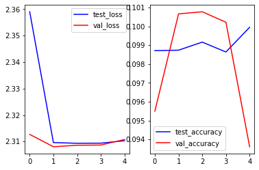

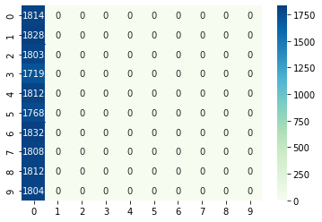

```python
%%time
# tryout the NNimg framework
hidden_layer = 10
hidden_neurons = 20
learning_rate = 1e-2
Lambda = 0.25
epochs = 5

data = [h5X_train,h5Y_train,h5X_test,h5Y_test]
params = [hidden_layer,hidden_neurons,learning_rate,Lambda,0.5]

p_acc,p_epoch = NNimg(data,params,epochs,verbose = True)
print(p_acc,p_epoch)
```

The losses are huge and the learning loss doesn't seem to reduce, inferring that the model might have hit a local minima or the learning rate is to huge to descend further

```python
# lets create parameter gridpoints
hidden_layers = np.arange(2,10,2)
hidden_neurons = np.arange(20,100,10)
learning_rates = [1e-4,1e-5,1e-6]
Lambdas = [0.25,0.5]
dos = np.arange(0.1,0.5,0.1)

pgrid = [[hl,hn,lr,lm,do]
           for hl in hidden_layers
           for hn in hidden_neurons
           for lr in learning_rates
           for lm in Lambdas
           for do in dos]

print("number of grid points: ",len(pgrid))
```

```
number of grid points:  768
```

```python
#file = open("NN_img_tuning.har",'w') # reset log file
#file.close()

# above file not re-created after setting up a good hypertuning framework
# hence above line commented

results = [] # reset local log

file = open("NN_img_tuning.har",'rb')
read = True
while read:
    try:
        results.append(pickle.load(file))
    except:
        read = False
file.close()

if len(results)>0:
    respg = [i[:-2] for i in results]

    for gp in respg:
        try:
            pgrid.remove(gp)
        except:
            pass

print("grid points remaining: ",len(pgrid))
```

```
grid points remaining:  718
```

```python
%%time
# perform random grid search
epochs = 20
nSearch = 2
data = [h5X_train,h5Y_train,h5X_test,h5Y_test]
for niter,iter in enumerate(np.random.randint(0,len(pgrid),nSearch)):
    params = pgrid[iter]
    p_acc,p_epoch = NNimg(data,params,epochs,verbose = False)

    storage = pgrid[iter].copy()
    storage.append(p_acc)
    storage.append(p_epoch)
    file = open("NN_img_tuning.har",'ab')
    pickle.dump(storage,file)
    file.close()

    print("iter %d / %d"%(niter+1,nSearch))
    print(p_acc,p_epoch)
    print("="*50)

file = open("NN_img_tuning.har",'rb')
read = True
while read:
    try:
        results.append(pickle.load(file))
    except:
        read = False
file.close()

cols=["HiddenLayers","HiddenNeurons","LearningRate","Lambda",
         "DropOut","PeakAccuracy","PeakEpoch"]

display(pd.DataFrame(results,columns=cols).sort_values(by="PeakAccuracy",ascending=False).head())
```

```
iter 1 / 2
0.6922777891159058 18
==================================================
iter 2 / 2
0.6381666660308838 19
==================================================
```

|  | HiddenLayers | HiddenNeurons | LearningRate | Lambda | DropOut | PeakAccuracy | PeakEpoch |
| --- | --- | --- | --- | --- | --- | --- | --- |
| 411 | 2 | 50 | 0.00001 | 0.25 | 0.3 | 0.814889 | 96 |
| 203 | 2 | 50 | 0.00001 | 0.25 | 0.3 | 0.814889 | 96 |
| 205 | 2 | 60 | 0.00010 | 0.25 | 0.1 | 0.812667 | 90 |
| 413 | 2 | 60 | 0.00010 | 0.25 | 0.1 | 0.812667 | 90 |
| 409 | 2 | 60 | 0.00010 | 0.25 | 0.1 | 0.801944 | 49 |

```
CPU times: user 13min 9s, sys: 27.5 s, total: 13min 36s
Wall time: 8min 14s
```

```python
results = [] # reset local log

file = open("NN_img_tuning.har",'rb')
read = True
while read:
    try:
        results.append(pickle.load(file))
    except:
        read = False
file.close()
print("log size: ",len(results))
```

```
log size:  210
```

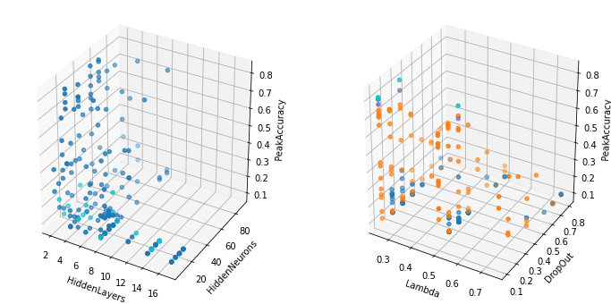

```python
fig = plt.figure(figsize=(12,6))

ax = fig.add_subplot(121, projection='3d')

x = [hl for [hl,hn,lr,lm,do,pa,pe] in results]
y = [hn for [hl,hn,lr,lm,do,pa,pe] in results]
z = [pa for [hl,hn,lr,lm,do,pa,pe] in results]
c = [lr for [hl,hn,lr,lm,do,pa,pe] in results]

ax.scatter(x, y, z, c=c, marker='o',cmap='tab10')
ax.set_xlabel('HiddenLayers')
ax.set_ylabel('HiddenNeurons')
ax.set_zlabel('PeakAccuracy')


ax = fig.add_subplot(122, projection='3d')

x = [lm for [hl,hn,lr,lm,do,pa,pe] in results]
y = [do for [hl,hn,lr,lm,do,pa,pe] in results]
z = [pa for [hl,hn,lr,lm,do,pa,pe] in results]
c = [pe for [hl,hn,lr,lm,do,pa,pe] in results]

ax.scatter(x, y, z, c=c, marker='o',cmap='tab10')
ax.set_xlabel('Lambda')
ax.set_ylabel('DropOut')
ax.set_zlabel('PeakAccuracy')
fig.show()
```

After recursively adjusting the parameter grid points, over 200 models have been studied and logged for performance and analysed as above. Let us review the to performers from above for further more epochs

```python
cols=["HiddenLayers","HiddenNeurons","LearningRate","Lambda",
         "DropOut","PeakAccuracy","PeakEpoch"]
respg=pd.DataFrame(results,columns=cols)
```

```python
testcases=list(respg.sort_values(by=["PeakEpoch","PeakAccuracy"],ascending=False).head(2).index)
testcases.extend(list(respg.sort_values(by=["PeakAccuracy","PeakEpoch"],ascending=False).head(2).index))
testcases=respg.loc[testcases,["HiddenLayers","HiddenNeurons","LearningRate","Lambda","DropOut"]].values
```

```python
%%time
# Choose the best among above result
epochs = 100
nSearch = len(testcases)
data = [h5X_train,h5Y_train,h5X_test,h5Y_test]
for params in testcases:

    [hl,hn,lr,lm,do]=params
    hl=int(hl)
    hn=int(hn)
    params=[hl,hn,lr,lm,do]

    p_acc,p_epoch = NNimg(data,params,epochs,verbose = False)

    storage = params.copy()
    storage.append(p_acc)
    storage.append(p_epoch)
    file = open("NN_img_tuning.har",'ab')
    pickle.dump(storage,file)
    file.close()

    print(p_acc,p_epoch)
    print("="*50)

file = open("NN_img_tuning.har",'rb')
read = True
while read:
    try:
        results.append(pickle.load(file))
    except:
        read = False
file.close()

cols=["HiddenLayers","HiddenNeurons","LearningRate","Lambda",
         "DropOut","PeakAccuracy","PeakEpoch"]

display(pd.DataFrame(results,columns=cols).sort_values(by="PeakAccuracy",ascending=False).head())
```

```
0.8010555505752563 99
==================================================
0.7676666378974915 99
==================================================
0.8148888945579529 96
==================================================
0.812666654586792 90
==================================================
```

|  | HiddenLayers | HiddenNeurons | LearningRate | Lambda | DropOut | PeakAccuracy | PeakEpoch |
| --- | --- | --- | --- | --- | --- | --- | --- |
| 422 | 2 | 50 | 0.00001 | 0.25 | 0.3 | 0.814889 | 96 |
| 413 | 2 | 50 | 0.00001 | 0.25 | 0.3 | 0.814889 | 96 |
| 203 | 2 | 50 | 0.00001 | 0.25 | 0.3 | 0.814889 | 96 |
| 423 | 2 | 60 | 0.00010 | 0.25 | 0.1 | 0.812667 | 90 |
| 415 | 2 | 60 | 0.00010 | 0.25 | 0.1 | 0.812667 | 90 |

```
CPU times: user 2h 6min, sys: 5min 3s, total: 2h 11min 3s
Wall time: 1h 19min 47s
```

It could be seen that the accuracy (or learning) has improved over the extra epochs. Let's evaluate the best model for the project statement

```
Model: "sequential_25"
_________________________________________________________________
 Layer (type)                Output Shape              Param #
=================================================================
 dense_144 (Dense)           (None, 1024)              1049600

 batch_normalization_114 (Ba  (None, 1024)             4096
 tchNormalization)

 dropout_114 (Dropout)       (None, 1024)              0

 dense_145 (Dense)           (None, 50)                51250

 batch_normalization_115 (Ba  (None, 50)               200
 tchNormalization)

 dropout_115 (Dropout)       (None, 50)                0

 dense_146 (Dense)           (None, 50)                2550

 batch_normalization_116 (Ba  (None, 50)               200
 tchNormalization)

 dropout_116 (Dropout)       (None, 50)                0

 dense_147 (Dense)           (None, 10)                510

=================================================================
Total params: 1,108,406
Trainable params: 1,106,158
Non-trainable params: 2,248
_________________________________________________________________
```

```
None
```

```
Loss     :1.001143
Accuracy :0.814889
CLASSIFICATION REPORT
               precision    recall  f1-score   support

           0      0.236     0.987     0.381      1814
           1      0.937     0.688     0.793      1828
           2      0.982     0.643     0.777      1803
           3      0.943     0.558     0.701      1719
           4      0.974     0.694     0.811      1812
           5      0.947     0.566     0.708      1768
           6      0.973     0.606     0.747      1832
           7      0.951     0.726     0.824      1808
           8      0.987     0.487     0.652      1812
           9      0.960     0.597     0.736      1804

    accuracy                          0.656     18000
   macro avg      0.889     0.655     0.713     18000
weighted avg      0.889     0.656     0.713     18000
```

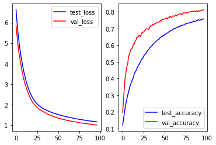

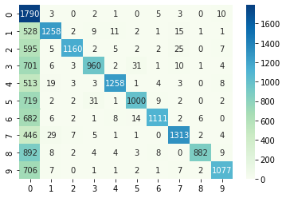

```python
epochs = 97
data = [h5X_train,h5Y_train,h5X_test,h5Y_test]
[hl,hn,lr,lm,do]=testcases[2]
hl=int(hl)
hn=int(hn)
params=[hl,hn,lr,lm,do]

p_acc,p_epoch = NNimg(data,params,epochs,verbose=True)
```

It could also be seen that the learning might continue for further more epochs before overfitting. The learning rate and gradient descent have been gradual making it an optimal learner. Considering the computational costs, the learner have been halted at 97 epochs.

Further the model have been evaluated on the test dataset for classification and various metrics have been displayed. It could be seen that there are more cases being classified as ZERO thus it's precision have been lost. Also the effective accuracy is found to be only 65.6%. But based on the learning curve, this framework could perform better with further training.

```python
%%shell
jupyter nbconvert --to html NN_Project_Hari.ipynb
```